# HW 07: Data Importing and Wrangling I

Hayley Laubinger

19 July 2020

Load tidyverse

```r
library(tidyverse)
```

## Limpets.csv

Load the limpet data

```r
limpets_data <- read_csv(file.path(file_path, "limpets.csv"))
```

Data is tidy

Use column arrangement

```r
col_types = "ncc"
```

Make sites factor column

```r
factor(limpets_data$Site, levels = c('PBL', 'KNRM', 'VBG', 'WP', 'PF', 'DP', 'SIO', 'CTZI', 'CTZ2', 'CNM'))
```

Boxplot of limpet data

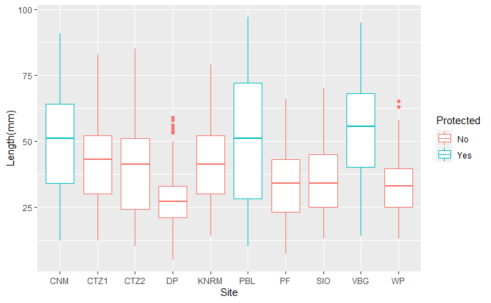

```r
ggplot(data = limpets_data) +
  geom_boxplot(mapping = aes(x = Site, y = Length, color = Protected)) +
  labs(x = "Site", y = "Length(mm)")
```

This is a boxplot of the limpet data, color coordinated by protected and unprotected.

### Roseate Terns

```r
?read_tsv
```

Load Roseate Terns data

```r
tern_data <- read_tsv(file.path(file_path, "roseate_terns.txt"))
```

Data is not tidy

Tidy the data

```r
tern_tidy <- tern_data %>%
  pivot_longer(`AR`:`JC`,
               names_to = "Site",
               values_to = "Population")
```

Remove Sites that are missing data

```r
complete_terns <- tern_data %>% filter(complete.cases(.))
```

Make a line plot for the data

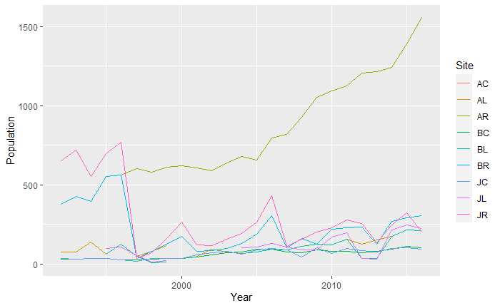

```r
tern_tidy %>%
  ggplot() +
  geom_line(mapping = aes(x = year, y = Population, color = Site)) +
  labs(x = 'Year', y = 'Population')
```

### Backlip Abalone

#### Chunk 1: Import, remove the first column, then make a boxplot of height differences among the three types.

```r
abalone_data <- read_csv(file.path(file_path, "abalone.csv"))
```

```r
abalone_data <- read_csv(here ("data","abalone.csv"))
select(abalone_data,-(X1))
```

| Type | LongestShell | Diameter | Height | WholeWeight | ShuckedWeight | VisceraWeight | ShellWeight | Rings |
| --- | --- | --- | --- | --- | --- | --- | --- | --- |
| M | 0.455 | 0.365 | 0.095 | 0.5140 | 0.2245 | 0.1010 | 0.1500 | 15 |
| M | 0.350 | 0.265 | 0.090 | 0.2255 | 0.0995 | 0.0485 | 0.0700 | 7 |
| F | 0.530 | 0.420 | 0.135 | 0.6770 | 0.2565 | 0.1415 | 0.2100 | 9 |
| M | 0.440 | 0.365 | 0.125 | 0.5160 | 0.2155 | 0.1140 | 0.1550 | 10 |
| I | 0.330 | 0.255 | 0.080 | 0.2050 | 0.0895 | 0.0395 | 0.0550 | 7 |
| I | 0.425 | 0.300 | 0.095 | 0.3515 | 0.1410 | 0.0775 | 0.1200 | 8 |
| F | 0.530 | 0.415 | 0.150 | 0.7775 | 0.2370 | 0.1415 | 0.3300 | 20 |
| F | 0.545 | 0.425 | 0.125 | 0.7680 | 0.2940 | 0.1495 | 0.2600 | 16 |
| M | 0.475 | 0.370 | 0.125 | 0.5095 | 0.2165 | 0.1125 | 0.1650 | 9 |
| F | 0.550 | 0.440 | 0.150 | 0.8945 | 0.3145 | 0.1510 | 0.3200 | 19 |

[output cut: 990 more lines]

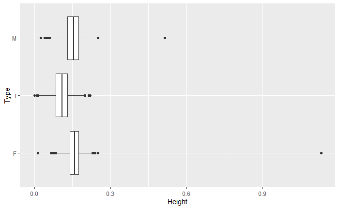

```r
ggplot(data=abalone_data)+
  geom_boxplot(mapping=aes(x=Height,y=Type))
```

This boxplot shows the height vs type of abalone data.The outliers one in F and one in the M.

#### Chunk 2: Make a scatterplot to see if height appears to correlate with rings. Rings is a measure used to estimate age. Based on the graph, are the extraordinarily large individuals really old individuals?

```r
ggplot(data = abalone_data)+
  geom_point(mapping=aes(x=Rings, y-Height))
```

```
Error in FUN(X[[i]], ...) : object 'y' not found
```

#### Chunk 3: remove outliers by filtering. Make ordered factor. Remake scatterplot

```r
abalone_filtered <- filter(abalone_data, Height <= 0.4)
factor(abalone_filtered$Type, level = 'I', 'F', 'M')
```

[output not shown]

[output cut: 46 more lines]

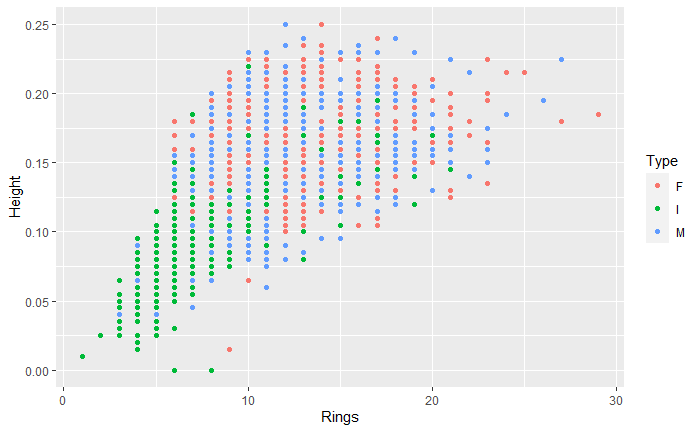

```r
abalone_filtered %>%
  ggplot() +
  geom_point(mapping = aes(x = Rings, y = Height, color = Type))
```

Immature abalone seem to be smaller than mature. The male and female immature seems to relatively similar in size.

#### Chunk 4: print records and change those with 0 height to NA. replot

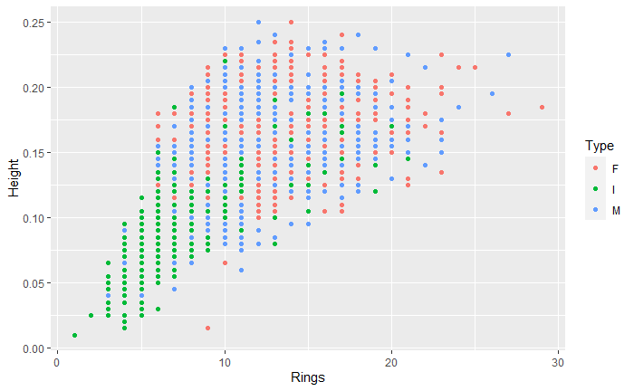

```r
abalone_filtered[abalone_filtered$Height == 0, 'Height'] <- NA
abalone_filtered %>%
  ggplot() +
  geom_point(mapping = aes(x = Rings, y = Height, color = Type))
```

This removed two rows of data that contained missing values.

#### Chunk 5: Make two scatterplots of your choice

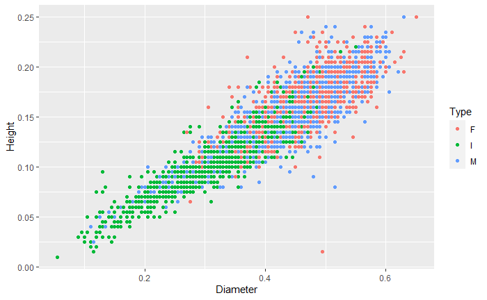

```r
abalone_filtered %>%
  ggplot() +
  geom_point(mapping = aes(x = Diameter, y = Height, color = Type))
```

The immature abalone have less height and diameter. As they mature, they increase in diameter and height. Gender does not seem to have an affect.

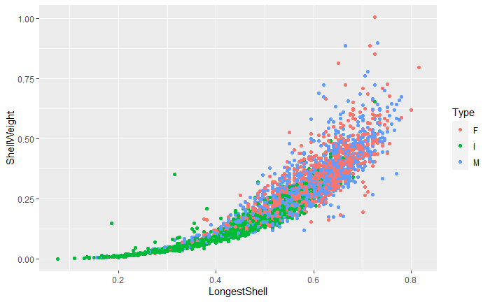

```r
abalone_filtered %>%
  ggplot() +
  geom_point(mapping = aes(x = LongestShell, y = ShellWeight, color = Type))
```

The immature abalone have shorter shells, as well as less shellweight. As they become mature, shell length and weight increase.

### Darters

#### Load the darter data. Assign names to column with width included. Make riffle an unordered factor. Make major_type an ordered factor

Load the data

```r
?read_fwf
```

```r
library(tidyverse)
```

```r
darters_data <- read_fwf (here("data", "darter.txt"), fwf_widths(c(3, 11, 1, 1, 1, 3, 4, 4, 4, 3, 3, 2, 2)), comment = '#')
darters_named <- darters_data %>% rename(ID=X1,Species=X2,Riffle=X3,Age=X4,Sex=X5,Length=X6,Depth=X7,Velocity=X8,Temperature=X9,Maj_Sub=X10,Min_Sub=X11,Maj_Type=X12,Min_Type=X13)
darters_named$Riffle <- factor(darters_named$Riffle,levels=c('1','2'))
darters_named$Maj_Type <- factor(darters_named$Maj_Type,levels=c('s','fg','sg','lg','c'),ordered=TRUE)
```

#### Chunk 2: Use filter to remove zonale and tetrazonum. Remove min_sub and min_type. rename maj_sub and maj_type.

```r
darters_tidy <- darters_named %>%
  filter(Species=="blennioides"|Species=="caeruleum"|Species=="spectabile") %>%
  rename(
    Major_Substrate = Maj_Sub,
    Major_Type = Maj_Type)
select(darters_tidy,-(c(Min_Type,Min_Sub))) %>%
  arrange(darters_tidy,ID) %>%
  drop_na()
```

| ID | Species | Riffle | Age | Sex | Length | Depth | Velocity | Temperature | Major_Substrate | Major_Type |
| --- | --- | --- | --- | --- | --- | --- | --- | --- | --- | --- |
| 2 | blennioides | 1 | 0 | m | 2.9 | 28.0 | 0.47 | 28.1 | 0.7 | c |
| 3 | blennioides | 1 | 1 | f | 3.1 | 8.0 | 0.39 | 30.2 | 0.6 | lg |
| 4 | blennioides | 1 | 1 | f | 3.3 | 59.0 | 0.34 | 25.4 | 0.5 | sg |
| 5 | blennioides | 1 | 1 | m | 3.5 | 27.0 | 0.34 | 28.0 | 0.8 | lg |
| 6 | blennioides | 1 | 1 | m | 3.6 | 7.0 | 0.36 | 24.0 | 0.6 | sg |
| 7 | blennioides | 1 | 1 | m | 3.7 | 13.5 | 0.61 | 29.4 | 0.6 | lg |
| 8 | blennioides | 1 | 1 | m | 3.7 | 27.0 | 0.34 | 28.0 | 0.5 | lg |
| 9 | blennioides | 1 | 1 | f | 3.8 | 11.5 | 0.34 | 30.0 | 0.6 | lg |
| 10 | blennioides | 1 | 1 | m | 3.8 | 12.0 | 0.39 | 29.8 | 0.6 | lg |
| 11 | blennioides | 2 | 0 | f | 2.7 | 13.0 | 0.34 | 22.2 | 0.5 | lg |

[output cut: 108 more lines]

```r
library(here)
```

#### Plot 1: Plot 1 Plot length as a function of depth. Map species to color and shape. What differences do you see between the two riffles?

Plot 1

```r
darter_renamed %>%
  ggplot() +
  geom_point(mapping = aes(x = Depth, y = Length, Color = Species, Shape = Species)) +
  facet_wrap(~ Riffle, rnow = 1)
```

```
Error in eval(lhs, parent, parent) : object 'darter_renamed' not found
```

Plot 2

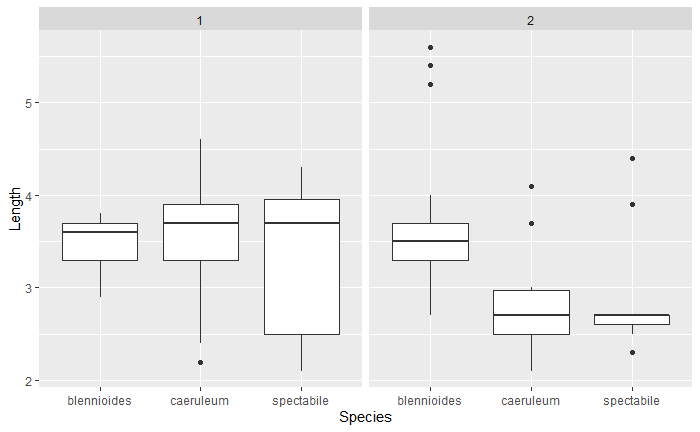

```r
ggplot(data=darters_tidy)+
  geom_boxplot(mapping=aes(x=Species, y=Length))+
  facet_wrap(~Riffle,ncol=2)
```

```r
ggplot(data=darters_tidy)+
  geom_boxplot(mapping=aes(x=major_substrate,y=Length))+
  facet_grid(Species~Riffle)
```

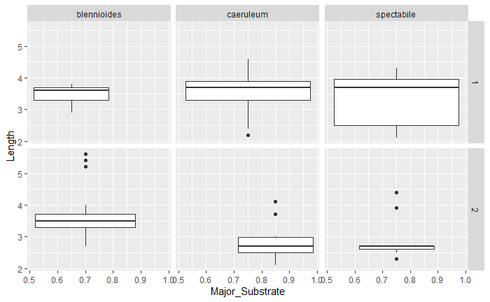

```r
ggplot(data=darters_tidy)+
  geom_boxplot(mapping=aes(x=Major_Substrate,y=Length))+
  facet_grid(Riffle~Species)
```

This has created a better comparison of the data. There are still more outliers in Riffle 2, but you can interpret the data easier.